# Sign language digits recognition

Problem comprises of sets of pictures of hand gestures depiction digits 0-9 in sign language. Given notebook contains step by step description of creation image classifier using Deep Learning methods.

Data used for classifier training was taken from Turkey Ankara Ayrancı Anadolu High School's Sign Language Digits Dataset available on https://github.com/ardamavi/Sign-Language-Digits-Dataset.

Sample pictures of each digit represented in sign language are given below:

[figure not shown]

- 0

[figure not shown]

- 1

[figure not shown]

- 2

[figure not shown]

- 3

[figure not shown]

- 4

[figure not shown]

- 5

[figure not shown]

- 6

[figure not shown]

- 7

[figure not shown]

- 8

[figure not shown]

- 9.

Dataset is sorted and classified, each digit representation is located in different folder denoted by digit value

Sign-Language-Digits-Dataset>

```
    |  Dataset>
            |  0
            |  1
            |  2
            |  3
            |  4
            |  5
            |  6
            |  7
            |  8
            |  9
```

# Data acquisition and initial processing

Datastet is cloned from git repository to colab disc space.

```python
!git clone https://github.com/ardamavi/Sign-Language-Digits-Dataset.git
```

Sequently we install library "split-folders" for easy data distribution.

```python
!pip install split-folders
```

Below split-folders takes elements form folder '/Dataset' and splits elements into training, validation and test sets.

```python
# data preparation for ImageAI
import split_folders

# Split with a ratio.
# To only split into training and validation set, set a tuple to `ratio`, i.e, `(.8, .2)`.
split_folders.ratio('Sign-Language-Digits-Dataset/Dataset', output="ImageAI_Dataset", seed=1337, ratio=(.8, .1, .1)) # default values






# Split val/test with a fixed number of items e.g. 100 for each set.
# To only split into training and validation set, use a single number to `fixed`, i.e., `10`.

###split_folders.fixed('input_folder', output="output", seed=1337, fixed=(100, 100), oversample=False) # default values
```

# Installing ImageAI and dependencies

ImageAI is a Python library created for fast deployment and integration of Computer Vision with Artificial Intelligence features.

It covers Image Recognition, Object Detection, Video Detection & Analysis, Custom Image Recognition etc.

More detailed description can be found on official website http://imageai.org/.

Dependencies :

- Python 3.5.1 (and later versions) Download (Support for Python 2.7 coming soon)
- Tensorflow 1.4.0 (and later versions)
- Numpy 1.13.1 (and later versions)
- SciPy 0.19.1 (and later versions)
- OpenCV
- Pillow
- Matplotlib
- h5py
- Keras 2.x

```python
!pip install pillow
!pip install h5py
```

```python
#ImageAI installation

!pip install https://github.com/OlafenwaMoses/ImageAI/releases/download/2.0.2/imageai-2.0.2-py3-none-any.whl
```

# Model Preparation and training -Image AI

```
model_trainerResNet = ModelTraining()

model_trainerResNet.setModelTypeAsResNet() # setting type of neural network model among available models :  SqueezeNet, DenseNet, ResNet, inceptionV3

model_trainerResNet.setDataDirectory("ImageAI_Dataset") # directory of dataset splitted into training and validation sets, classes are decoded from directories containing data relevant to given class

model_trainerResNet.trainModel(num_objects=10, num_experiments=20, enhance_data=True, batch_size=64, show_network_summary=True)
```

[output not shown]

```
W0708 07:05:22.683363 140333595641728 callbacks.py:875] `period` argument is deprecated. Please use `save_freq` to specify the frequency in number of samples seen.
```

[output not shown]

[output cut: 346 more lines]

```
Epoch 00006: saving model to ImageAI_Dataset/models/model_ex-006_acc-0.083333.h5
Epoch 00007: saving model to ImageAI_Dataset/models/model_ex-007_acc-0.083333.h5
Epoch 00008: saving model to ImageAI_Dataset/models/model_ex-008_acc-0.083333.h5
Epoch 00009: saving model to ImageAI_Dataset/models/model_ex-009_acc-0.098958.h5
Epoch 00010: saving model to ImageAI_Dataset/models/model_ex-010_acc-0.083333.h5
Epoch 00011: saving model to ImageAI_Dataset/models/model_ex-011_acc-0.098958.h5
Epoch 00012: saving model to ImageAI_Dataset/models/model_ex-012_acc-0.098958.h5
Epoch 00013: saving model to ImageAI_Dataset/models/model_ex-013_acc-0.104167.h5
Epoch 00014: saving model to ImageAI_Dataset/models/model_ex-014_acc-0.166667.h5
Epoch 00015: saving model to ImageAI_Dataset/models/model_ex-015_acc-0.255208.h5
Epoch 00016: saving model to ImageAI_Dataset/models/model_ex-016_acc-0.302083.h5
Epoch 00017: saving model to ImageAI_Dataset/models/model_ex-017_acc-0.317708.h5
Epoch 00018: saving model to ImageAI_Dataset/models/model_ex-018_acc-0.385417.h5
Epoch 00019: saving model to ImageAI_Dataset/models/model_ex-019_acc-0.500000.h5
Epoch 00020: saving model to ImageAI_Dataset/models/model_ex-020_acc-0.697917.h5
```

# Model prediction

Few examples comprising of 0,...,9 numbers represented in sign language not included into training and validation data.

```python
from imageai.Prediction.Custom import CustomImagePrediction
import os
from google.colab.patches import cv2_imshow
import cv2
execution_path = os.getcwd()


prediction = CustomImagePrediction()
prediction.setModelTypeAsResNet()
prediction.setModelPath("ImageAI_Dataset/models/model_ex-020_acc-0.697917.h5")
prediction.setJsonPath("ImageAI_Dataset/json/model_class.json")
prediction.loadModel(num_objects=10)


predictions, probabilities = prediction.predictImage(os.path.join(execution_path, "Sign-Language-Digits-Dataset/Examples/example_0.JPG"), result_count=10)

cv2_imshow(cv2.imread("Sign-Language-Digits-Dataset/Examples/example_0.JPG"))

for eachPrediction, eachProbability in zip(predictions, probabilities):
  print(eachPrediction + " : " + eachProbability)
```

```
WARNING: Logging before flag parsing goes to stderr.
W0708 15:49:22.601294 139675628734336 deprecation.py:506] From /usr/local/lib/python3.6/dist-packages/tensorflow/python/ops/init_ops.py:1251: calling VarianceScaling.__init__ (from tensorflow.python.ops.init_ops) with dtype is deprecated and will be removed in a future version.
Instructions for updating:
Call initializer instance with the dtype argument instead of passing it to the constructor
```

```
0 : 99.82132911682129
9 : 0.1757984864525497
4 : 0.001441701351723168
1 : 0.00077801623774576
8 : 0.0002347328518226277
5 : 0.00022008334781276062
7 : 0.00020818897610297427
6 : 1.940224647611899e-07
2 : 1.1551211098748126e-07
3 : 2.0556460700316137e-08
```

```python
predictions, probabilities = prediction.predictImage(os.path.join(execution_path, "Sign-Language-Digits-Dataset/Examples/example_1.JPG"), result_count=10)

cv2_imshow(cv2.imread("Sign-Language-Digits-Dataset/Examples/example_1.JPG"))

for eachPrediction, eachProbability in zip(predictions, probabilities):
  print(eachPrediction + " : " + eachProbability)

predictions, probabilities = prediction.predictImage(os.path.join(execution_path, "Sign-Language-Digits-Dataset/Examples/example_2.JPG"), result_count=10)

cv2_imshow(cv2.imread("Sign-Language-Digits-Dataset/Examples/example_2.JPG"))

for eachPrediction, eachProbability in zip(predictions, probabilities):
  print(eachPrediction + " : " + eachProbability)

predictions, probabilities = prediction.predictImage(os.path.join(execution_path, "Sign-Language-Digits-Dataset/Examples/example_3.JPG"), result_count=10)

cv2_imshow(cv2.imread("Sign-Language-Digits-Dataset/Examples/example_3.JPG"))

for eachPrediction, eachProbability in zip(predictions, probabilities):
  print(eachPrediction + " : " + eachProbability)

predictions, probabilities = prediction.predictImage(os.path.join(execution_path, "Sign-Language-Digits-Dataset/Examples/example_4.JPG"), result_count=10)

cv2_imshow(cv2.imread("Sign-Language-Digits-Dataset/Examples/example_4.JPG"))

for eachPrediction, eachProbability in zip(predictions, probabilities):
  print(eachPrediction + " : " + eachProbability)

predictions, probabilities = prediction.predictImage(os.path.join(execution_path, "Sign-Language-Digits-Dataset/Examples/example_5.JPG"), result_count=10)

cv2_imshow(cv2.imread("Sign-Language-Digits-Dataset/Examples/example_5.JPG"))

for eachPrediction, eachProbability in zip(predictions, probabilities):
  print(eachPrediction + " : " + eachProbability)

predictions, probabilities = prediction.predictImage(os.path.join(execution_path, "Sign-Language-Digits-Dataset/Examples/example_6.JPG"), result_count=10)

cv2_imshow(cv2.imread("Sign-Language-Digits-Dataset/Examples/example_6.JPG"))

for eachPrediction, eachProbability in zip(predictions, probabilities):
  print(eachPrediction + " : " + eachProbability)

predictions, probabilities = prediction.predictImage(os.path.join(execution_path, "Sign-Language-Digits-Dataset/Examples/example_7.JPG"), result_count=10)

cv2_imshow(cv2.imread("Sign-Language-Digits-Dataset/Examples/example_7.JPG"))

for eachPrediction, eachProbability in zip(predictions, probabilities):
  print(eachPrediction + " : " + eachProbability)

predictions, probabilities = prediction.predictImage(os.path.join(execution_path, "Sign-Language-Digits-Dataset/Examples/example_8.JPG"), result_count=10)

cv2_imshow(cv2.imread("Sign-Language-Digits-Dataset/Examples/example_8.JPG"))

for eachPrediction, eachProbability in zip(predictions, probabilities):
  print(eachPrediction + " : " + eachProbability)

predictions, probabilities = prediction.predictImage(os.path.join(execution_path, "Sign-Language-Digits-Dataset/Examples/example_9.JPG"), result_count=10)

cv2_imshow(cv2.imread("Sign-Language-Digits-Dataset/Examples/example_9.JPG"))

for eachPrediction, eachProbability in zip(predictions, probabilities):
  print(eachPrediction + " : " + eachProbability)
```

```
1 : 99.5297372341156
9 : 0.342230056412518
3 : 0.09110391256399453
2 : 0.031867437064647675
8 : 0.004965262633049861
0 : 9.686502835393185e-05
6 : 3.7068545566398825e-06
7 : 1.9394827077690024e-06
4 : 1.5706431710782454e-07
5 : 2.0748185114438655e-08
```

```
2 : 86.72589063644409
6 : 8.957188576459885
7 : 2.605115994811058
3 : 1.0613157413899899
8 : 0.5015591159462929
9 : 0.10302907321602106
4 : 0.032474647741764784
1 : 0.012317349319346249
0 : 0.0011025726962543558
5 : 5.4826973183708105e-06
```

```
5 : 83.6277186870575
9 : 7.141221314668655
8 : 5.131926015019417
3 : 3.6958377808332443
7 : 0.2878086408600211
4 : 0.11500319233164191
0 : 0.0003346209041410475
1 : 0.00012647606126847677
2 : 1.3176205015952291e-05
6 : 7.266213408740896e-07
```

```
4 : 99.14348721504211
5 : 0.8398901671171188
0 : 0.01172792399302125
9 : 0.0031685678550275043
6 : 0.0010209585525444709
8 : 0.0004461207481654128
7 : 0.00026366069505456835
3 : 2.7283350578777288e-08
2 : 2.7273255875925884e-08
1 : 1.1642926900368167e-08
```

```
5 : 99.97950196266174
4 : 0.012321541726123542
9 : 0.005706000592908822
8 : 0.002470906838425435
7 : 4.540882869719098e-06
0 : 1.2993381481862798e-06
3 : 3.810392001923901e-08
1 : 5.971299843476885e-11
6 : 3.8651570279883e-13
2 : 3.278375641992153e-14
```

```
6 : 93.08664202690125
4 : 5.354733392596245
2 : 1.045476458966732
7 : 0.2385754371061921
3 : 0.16209017485380173
8 : 0.042683957144618034
0 : 0.0418835727032274
9 : 0.020788537221960723
5 : 0.00705414277035743
1 : 7.357671734098403e-05
```

```
5 : 41.599759459495544
3 : 33.62948000431061
9 : 18.1628555059433
7 : 3.865640237927437
8 : 2.1258432418107986
4 : 0.6066638976335526
0 : 0.0070594847784377635
2 : 0.0016290139683405869
1 : 0.0009509187293588184
6 : 0.00012607596318048309
```

```
8 : 99.86417889595032
9 : 0.07500573992729187
7 : 0.057763775112107396
3 : 0.001427194001735188
5 : 0.0007394220574497012
1 : 0.0005875805982213933
4 : 0.0002960842039101408
0 : 1.01485028380921e-05
2 : 4.0580538929191334e-07
6 : 1.8478993335513394e-08
```

```
9 : 99.91663694381714
8 : 0.03411386860534549
5 : 0.03346993762534112
4 : 0.012265121040400118
0 : 0.0026916415663436055
1 : 0.00039236033444467466
7 : 0.00021674188701581443
3 : 0.00021084435957163805
2 : 1.1123652221556313e-06
6 : 1.884624900583276e-07
```

```python
# Run this cell to mount your Google Drive.
from google.colab import drive
drive.mount('/content/drive')
```

[output not shown]

```
Should be seven
```

[figure not shown]

```
8 : 48.53440523147583
9 : 47.39125669002533
4 : 2.6996247470378876
5 : 1.192066166549921
7 : 0.18211357528343797
3 : 0.0005364237949834205
0 : 2.4471549786575508e-08
1 : 9.037362004582494e-10
6 : 7.314820000799485e-12
2 : 9.291735437978125e-13
```

```python
predictions, probabilities = prediction.predictImage(os.path.join(execution_path, "drive/My Drive/Inżynieria_obliczeniowa/Deep learning/IMG_20190612_205456.jpg"), result_count=10)
print("Should be seven")
cv2_imshow(cv2.resize(cv2.imread("drive/My Drive/Inżynieria_obliczeniowa/Deep learning/IMG_20190612_205456.jpg"),(400, 400)))

for eachPrediction, eachProbability in zip(predictions, probabilities):
  print(eachPrediction + " : " + eachProbability)
```

```
Should be three
```

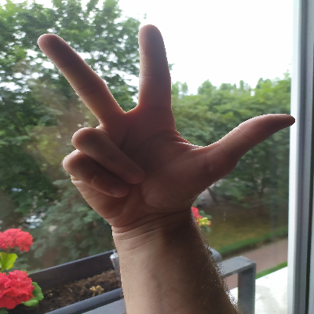

```
4 : 94.97976303100586
5 : 1.7046798020601273
9 : 1.5179126523435116
8 : 1.5134287998080254
7 : 0.2703850157558918
3 : 0.013834003766532987
6 : 1.0979368525454447e-06
0 : 1.9953276808593046e-07
2 : 2.158789856945842e-10
1 : 1.3659327575271663e-10
```

```python
predictions, probabilities = prediction.predictImage(os.path.join(execution_path, "drive/My Drive/Inżynieria_obliczeniowa/Deep learning/IMG_20190708_172541.jpg"), result_count=10)
print("Should be three")
cv2_imshow(cv2.resize(cv2.imread("drive/My Drive/Inżynieria_obliczeniowa/Deep learning/IMG_20190708_172541.jpg"),(400, 400)))

for eachPrediction, eachProbability in zip(predictions, probabilities):
  print(eachPrediction + " : " + eachProbability)
```

```
Should be three
```

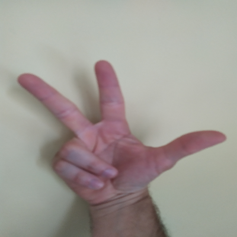

```
8 : 70.1272964477539
9 : 17.07140803337097
0 : 6.884627789258957
7 : 2.271793968975544
5 : 2.1662743762135506
4 : 1.391913928091526
1 : 0.08532956708222628
6 : 0.0007628832918271655
2 : 0.00047387343329319265
3 : 0.0001261066245206166
```

```python
predictions, probabilities = prediction.predictImage(os.path.join(execution_path, "drive/My Drive/Inżynieria_obliczeniowa/Deep learning/IMG_20190708_172557.jpg"), result_count=10)
print("Should be three")
cv2_imshow(cv2.resize(cv2.imread("drive/My Drive/Inżynieria_obliczeniowa/Deep learning/IMG_20190708_172557.jpg"),(400, 400)))

for eachPrediction, eachProbability in zip(predictions, probabilities):
  print(eachPrediction + " : " + eachProbability)
```

```
Should be seven
```

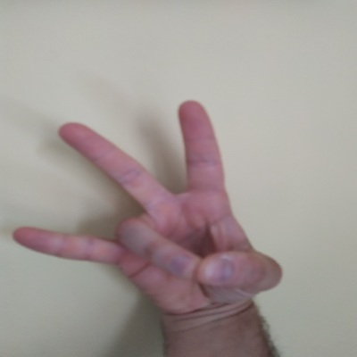

```
0 : 62.958282232284546
9 : 20.516575872898102
5 : 10.722967982292175
8 : 3.7852931767702103
4 : 1.9016431644558907
7 : 0.11349421693012118
1 : 0.0017078818927984685
6 : 3.446918412919331e-05
3 : 5.3530552435177015e-06
2 : 1.9728393141349443e-06
```

```python
predictions, probabilities = prediction.predictImage(os.path.join(execution_path, "drive/My Drive/Inżynieria_obliczeniowa/Deep learning/IMG_20190708_172601.jpg"), result_count=10)
print("Should be seven")
cv2_imshow(cv2.resize(cv2.imread("drive/My Drive/Inżynieria_obliczeniowa/Deep learning/IMG_20190708_172601.jpg"),(400, 400)))

for eachPrediction, eachProbability in zip(predictions, probabilities):
  print(eachPrediction + " : " + eachProbability)
```

# Conclusions

As shown above, trained model have made some mistakes in example set, it poorly recognised number "3" mistaking it with 5 and went especially bad on "7" not being able to decide if its "5" or "3".

5 with 41.599759459495544% accuracy, and 3 with 33.62948000431061%.

While it makes mistakes ontesting data, trained model is completely hopeless if it comes to oryginal data with complex backgroung, from this one can assume model to be highly biased because of the uniform background and need to be trained on more diverse dataset.

# References

1. https://towardsdatascience.com/understanding-and-coding-a-resnet-in-keras-446d7ff84d33